# Health Insurance Cross Sell - Part 01

Kleber Moreira

07/02/2024

# 1 Imports

```r
library(tidyverse)
library(janitor)
library(readr)
library(gtsummary)
library(summarytools)
library(kableExtra)
library(knitr)
library(gridExtra)
library(summarytools)
library(randomForest)
library(reshape2)
library(tidymodels)
```

# 2 Data Collection

```r
df <- read_csv("dataset/train.csv")
glimpse(df)
```

```
## Rows: 381,109
## Columns: 12
## $ id                   <dbl> 1, 2, 3, 4, 5, 6, 7, 8, 9, 10, 11, 12, 13, 14, 15…
## $ Gender               <chr> "Male", "Male", "Male", "Male", "Female", "Female…
## $ Age                  <dbl> 44, 76, 47, 21, 29, 24, 23, 56, 24, 32, 47, 24, 4…
## $ Driving_License      <dbl> 1, 1, 1, 1, 1, 1, 1, 1, 1, 1, 1, 1, 1, 1, 1, 1, 1…
## $ Region_Code          <dbl> 28, 3, 28, 11, 41, 33, 11, 28, 3, 6, 35, 50, 15, …
## $ Previously_Insured   <dbl> 0, 0, 0, 1, 1, 0, 0, 0, 1, 1, 0, 1, 1, 0, 1, 0, 0…
## $ Vehicle_Age          <chr> "> 2 Years", "1-2 Year", "> 2 Years", "< 1 Year",…
## $ Vehicle_Damage       <chr> "Yes", "No", "Yes", "No", "No", "Yes", "Yes", "Ye…
## $ Annual_Premium       <dbl> 40454, 33536, 38294, 28619, 27496, 2630, 23367, 3…
## $ Policy_Sales_Channel <dbl> 26, 26, 26, 152, 152, 160, 152, 26, 152, 152, 124…
## $ Vintage              <dbl> 217, 183, 27, 203, 39, 176, 249, 72, 28, 80, 46, …
## $ Response             <dbl> 1, 0, 1, 0, 0, 0, 0, 1, 0, 0, 1, 0, 0, 0, 0, 1, 0…
```

# 3 Data Cleaning

```r
df1 <- janitor::clean_names(df) %>%
  rename(days_associated = vintage,
         health_annual_paid = annual_premium) %>%
  mutate(
    across(where(is.character), tolower),
    driving_license = ifelse(driving_license == 1, "yes", "no"),
    previously_insured = ifelse(previously_insured == 1, "yes", "no"),
    response = ifelse(response == 1, "yes", "no"),
    vehicle_age = case_when(
      vehicle_age == "< 1 year" ~ "below_1_year",
      vehicle_age == "1-2 year" ~ "between_1_2_years",
      vehicle_age == "> 2 years" ~ "over_2_years"
    )
  ) %>%
  mutate_if(is.character, as.factor) %>%
  mutate(response = factor(response, levels = c("yes", "no")),
         driving_license = factor(driving_license, levels = c("yes", "no")),
         previously_insured = factor(previously_insured, levels = c("yes", "no")),
         vehicle_damage = factor(vehicle_damage, levels = c("yes", "no"))
         )

glimpse(df1)
```

```
## Rows: 381,109
## Columns: 12
## $ id                   <dbl> 1, 2, 3, 4, 5, 6, 7, 8, 9, 10, 11, 12, 13, 14, 15…
## $ gender               <fct> male, male, male, male, female, female, male, fem…
## $ age                  <dbl> 44, 76, 47, 21, 29, 24, 23, 56, 24, 32, 47, 24, 4…
## $ driving_license      <fct> yes, yes, yes, yes, yes, yes, yes, yes, yes, yes,…
## $ region_code          <dbl> 28, 3, 28, 11, 41, 33, 11, 28, 3, 6, 35, 50, 15, …
## $ previously_insured   <fct> no, no, no, yes, yes, no, no, no, yes, yes, no, y…
## $ vehicle_age          <fct> over_2_years, between_1_2_years, over_2_years, be…
## $ vehicle_damage       <fct> yes, no, yes, no, no, yes, yes, yes, no, no, yes,…
## $ health_annual_paid   <dbl> 40454, 33536, 38294, 28619, 27496, 2630, 23367, 3…
## $ policy_sales_channel <dbl> 26, 26, 26, 152, 152, 160, 152, 26, 152, 152, 124…
## $ days_associated      <dbl> 217, 183, 27, 203, 39, 176, 249, 72, 28, 80, 46, …
## $ response             <fct> yes, no, yes, no, no, no, no, yes, no, no, yes, n…
```

```r
# save df_cleaned as RDS
saveRDS(df1, "df_cleaned.rds")
```

## 3.1 Data Types

```r
variable_classes <- tibble(variables = names(df1),
       type = unlist(lapply(df1, class)))
variable_classes
```

| variables | type |
| --- | --- |
| id | numeric |
| gender | factor |
| age | numeric |
| driving_license | factor |
| region_code | numeric |
| previously_insured | factor |
| vehicle_age | factor |
| vehicle_damage | factor |
| health_annual_paid | numeric |
| policy_sales_channel | numeric |

[output cut: 2 more lines]

# 4 Column Description

```r
variables <- df1 %>% names()
description <- c(
  "Unique ID for the customer",
  "Gender of the customer",
  "Age of the customer",
  "Customer has DL (yes/no)",
  "Unique code for the region of the customer",
  "Customer already has Vehicle Insurance (yes/no)",
  "Age of the Vehicle",
  "Customer got his/her vehicle damaged in the past (yes/no)",
  "The amount customer needs to pay as premium in the year",
  "Anonymized Code for the channel of outreaching to the customer ie. Different Agents, Over Mail, Over Phone, In Person, etc.",
  "Number of Days, Customer has been associated with the company",
  "Customer is interested in car insurance (yes/no)"
)
df_description <- tibble(variables = variables,
       description = description)

kable(df_description, format = "html") %>%
  kableExtra::kable_styling(bootstrap_options = "striped",
                            full_width = FALSE)
```

| variables | description |
| --- | --- |
| id | Unique ID for the customer |
| gender | Gender of the customer |
| age | Age of the customer |
| driving_license | Customer has DL (yes/no) |
| region_code | Unique code for the region of the customer |
| previously_insured | Customer already has Vehicle Insurance (yes/no) |
| vehicle_age | Age of the Vehicle |
| vehicle_damage | Customer got his/her vehicle damaged in the past (yes/no) |
| health_annual_paid | The amount customer needs to pay as premium in the year |
| policy_sales_channel | Anonymized Code for the channel of outreaching to the customer ie. Different Agents, Over Mail, Over Phone, In Person, etc. |
| days_associated | Number of Days, Customer has been associated with the company |
| response | Customer is interested in car insurance (yes/no) |

# 5 Descriptive Statistics

```r
# Read cleaned data
df_cleaned <- readRDS("df_cleaned.rds")
glimpse(df_cleaned)
```

```
## Rows: 381,109
## Columns: 12
## $ id                   <dbl> 1, 2, 3, 4, 5, 6, 7, 8, 9, 10, 11, 12, 13, 14, 15…
## $ gender               <fct> male, male, male, male, female, female, male, fem…
## $ age                  <dbl> 44, 76, 47, 21, 29, 24, 23, 56, 24, 32, 47, 24, 4…
## $ driving_license      <fct> yes, yes, yes, yes, yes, yes, yes, yes, yes, yes,…
## $ region_code          <dbl> 28, 3, 28, 11, 41, 33, 11, 28, 3, 6, 35, 50, 15, …
## $ previously_insured   <fct> no, no, no, yes, yes, no, no, no, yes, yes, no, y…
## $ vehicle_age          <fct> over_2_years, between_1_2_years, over_2_years, be…
## $ vehicle_damage       <fct> yes, no, yes, no, no, yes, yes, yes, no, no, yes,…
## $ health_annual_paid   <dbl> 40454, 33536, 38294, 28619, 27496, 2630, 23367, 3…
## $ policy_sales_channel <dbl> 26, 26, 26, 152, 152, 160, 152, 26, 152, 152, 124…
## $ days_associated      <dbl> 217, 183, 27, 203, 39, 176, 249, 72, 28, 80, 46, …
## $ response             <fct> yes, no, yes, no, no, no, no, yes, no, no, yes, n…
```

- Check data structure so far:

```r
skimr::skim(df_cleaned)
```

Data summary

| Name | df_cleaned |
| --- | --- |
| Number of rows | 381109 |
| Number of columns | 12 |
| _______________________ |  |
| Column type frequency: |  |
| factor | 6 |
| numeric | 6 |
| ________________________ |  |
| Group variables | None |

**Variable type: factor**

| skim_variable | n_missing | complete_rate | ordered | n_unique | top_counts |
| --- | --- | --- | --- | --- | --- |
| gender | 0 | 1 | FALSE | 2 | mal: 206089, fem: 175020 |
| driving_license | 0 | 1 | FALSE | 2 | yes: 380297, no: 812 |
| previously_insured | 0 | 1 | FALSE | 2 | no: 206481, yes: 174628 |
| vehicle_age | 0 | 1 | FALSE | 3 | bet: 200316, bel: 164786, ove: 16007 |
| vehicle_damage | 0 | 1 | FALSE | 2 | yes: 192413, no: 188696 |
| response | 0 | 1 | FALSE | 2 | no: 334399, yes: 46710 |

**Variable type: numeric**

| skim_variable | n_missing | complete_rate | mean | sd | p0 | p25 | p50 | p75 | p100 | hist |
| --- | --- | --- | --- | --- | --- | --- | --- | --- | --- | --- |
| id | 0 | 1 | 190555.00 | 110016.84 | 1 | 95278 | 190555 | 285832 | 381109 | ▇▇▇▇▇ |
| age | 0 | 1 | 38.82 | 15.51 | 20 | 25 | 36 | 49 | 85 | ▇▃▃▂▁ |
| region_code | 0 | 1 | 26.39 | 13.23 | 0 | 15 | 28 | 35 | 52 | ▃▂▇▃▃ |
| health_annual_paid | 0 | 1 | 30564.39 | 17213.16 | 2630 | 24405 | 31669 | 39400 | 540165 | ▇▁▁▁▁ |
| policy_sales_channel | 0 | 1 | 112.03 | 54.20 | 1 | 29 | 133 | 152 | 163 | ▅▁▁▃▇ |
| days_associated | 0 | 1 | 154.35 | 83.67 | 10 | 82 | 154 | 227 | 299 | ▇▇▇▇▇ |

## 5.1 General overview

```r
df_cleaned %>%
  select(-id) %>%
  tbl_summary(
    type = list(response ~ "categorical",
                driving_license ~ "categorical",
                previously_insured ~ "categorical",
                vehicle_damage ~ "categorical"),
    digits = list(all_categorical() ~ c(0, 2))
  )
```

| **Characteristic** | **N = 381,109**<sup>1</sup> |
| --- | --- |
| gender |  |
| female | 175,020 (45.92%) |
| male | 206,089 (54.08%) |
| age | 36 (25, 49) |
| driving_license |  |
| yes | 380,297 (99.79%) |
| no | 812 (0.21%) |
| region_code | 28 (15, 35) |
| previously_insured |  |
| yes | 174,628 (45.82%) |
| no | 206,481 (54.18%) |
| vehicle_age |  |
| below_1_year | 164,786 (43.24%) |
| between_1_2_years | 200,316 (52.56%) |
| over_2_years | 16,007 (4.20%) |
| vehicle_damage |  |
| yes | 192,413 (50.49%) |
| no | 188,696 (49.51%) |
| health_annual_paid | 31,669 (24,405, 39,400) |
| policy_sales_channel | 133 (29, 152) |
| days_associated | 154 (82, 227) |
| response |  |
| yes | 46,710 (12.26%) |
| no | 334,399 (87.74%) |

<sup>1</sup> n (%); Median (IQR)

## 5.2 More detailed statistics

```r
num_attributes <- df_cleaned %>%
  select(age, health_annual_paid, days_associated)
```

```r
descriptive_tab <- summarytools::descr(num_attributes, style = "rmarkdown") %>% round(2)
```

[output not shown]

```r
kable(data.frame(descriptive_tab), format = "html") %>%
  kableExtra::kable_styling(bootstrap_options = "striped",
                            full_width = FALSE)
```

|  | age | days_associated | health_annual_paid |
| --- | --- | --- | --- |
| Mean | 38.82 | 154.35 | 30564.39 |
| Std.Dev | 15.51 | 83.67 | 17213.16 |
| Min | 20.00 | 10.00 | 2630.00 |
| Q1 | 25.00 | 82.00 | 24405.00 |
| Median | 36.00 | 154.00 | 31669.00 |
| Q3 | 49.00 | 227.00 | 39400.00 |
| Max | 85.00 | 299.00 | 540165.00 |
| MAD | 17.79 | 108.23 | 11125.43 |
| IQR | 24.00 | 145.00 | 14995.00 |
| CV | 0.40 | 0.54 | 0.56 |
| Skewness | 0.67 | 0.00 | 1.77 |
| SE.Skewness | 0.00 | 0.00 | 0.00 |
| Kurtosis | -0.57 | -1.20 | 34.00 |
| N.Valid | 381109.00 | 381109.00 | 381109.00 |
| Pct.Valid | 100.00 | 100.00 | 100.00 |

## 5.3 Visualization

- Numerical attributes

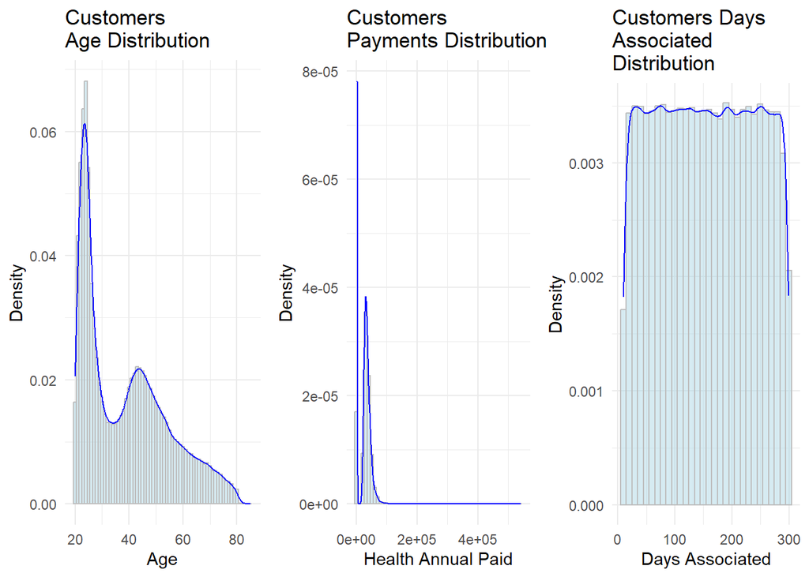

```r
# Age ---------------------
age_plt <- num_attributes %>%
  ggplot(aes(x = age)) +
  geom_histogram(aes(y = after_stat(density)), binwidth = 1,
                 color = "gray", fill = "lightblue", alpha = 0.5) + geom_density(color = "blue") +
  labs(x = "Age", y = "Density", title = "Customers \nAge Distribution") +
  theme_minimal()

#  health_annual_paid ---------------------
paid_plt <- num_attributes %>%
  ggplot(aes(x = health_annual_paid)) +
  geom_histogram(aes(y = after_stat(density)),
                 binwidth = 10000,
                 color = "gray", fill = "lightblue", alpha = 0.5) + geom_density(color = "blue") +
  labs(x = "Health Annual Paid", y = "Density", title = "Customers \nPayments Distribution") +
  theme_minimal()

#  days_associated ---------------------
days_plt <- num_attributes %>%
  ggplot(aes(x = days_associated)) +
  geom_histogram(aes(y = after_stat(density)),
                 color = "gray", fill = "lightblue", alpha = 0.5) + geom_density(color = "blue") +
  labs(x = "Days Associated", y = "Density", title = "Customers Days \nAssociated \nDistribution") +
  theme_minimal()


gridExtra::grid.arrange(age_plt, paid_plt, days_plt, ncol = 3)
```

- Categorical attributes:

```r
num_names <- names(num_attributes)
cat_attributes <- df_cleaned %>%
  select(-id, -one_of(num_names))
```

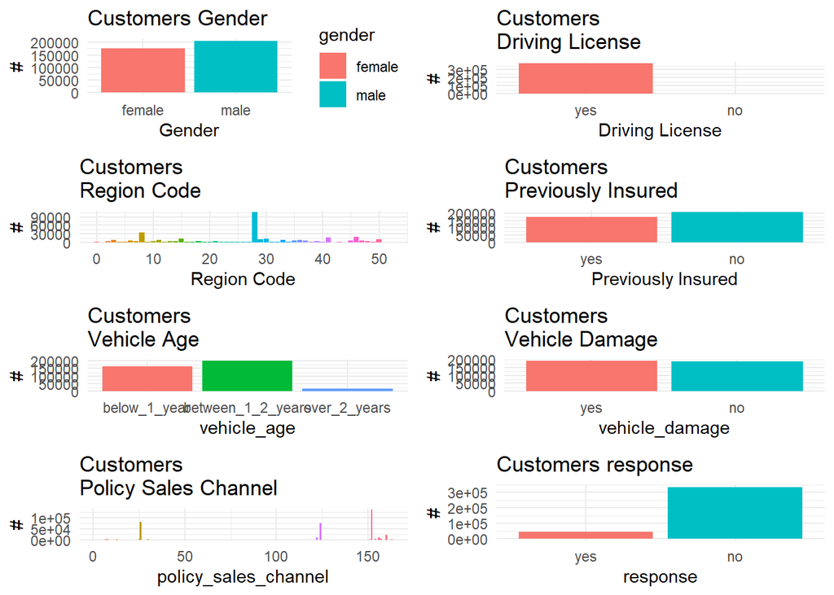

```r
gender_plt <- cat_attributes %>%
  ggplot(aes(x = gender)) +
  geom_bar(aes(fill = gender)) +
  labs(x = "Gender", y = "#",
       title = "Customers Gender") +
  theme_minimal()

driving_license_plt <- cat_attributes %>%
  ggplot(aes(x = driving_license)) +
  geom_bar(aes(fill = driving_license),
           show.legend = FALSE) +
  labs(x = "Driving License", y = "#",
       title = "Customers \nDriving License") +
  theme_minimal()

region_code_plt <- cat_attributes %>%
  ggplot(aes(x = region_code)) +
  geom_bar(aes(fill = factor(region_code)),
           show.legend = FALSE) +
  labs(x = "Region Code", y = "#",
       title = "Customers \nRegion Code") +
  theme_minimal()

previously_insured_plt <- cat_attributes %>%
  ggplot(aes(x = previously_insured)) +
  geom_bar(aes(fill = previously_insured),
           show.legend = FALSE) +
  labs(x = "Previously Insured", y = "#",
       title = "Customers \nPreviously Insured") +
  theme_minimal()

vehicle_age_plt <- cat_attributes %>%
  ggplot(aes(x = vehicle_age)) +
  geom_bar(aes(fill = vehicle_age),
           show.legend = FALSE) +
  labs(x = "vehicle_age", y = "#",
       title = "Customers \nVehicle Age") +
  theme_minimal()

vehicle_damage_plt <- cat_attributes %>%
  ggplot(aes(x = vehicle_damage)) +
  geom_bar(aes(fill = vehicle_damage),
           show.legend = FALSE) +
  labs(x = "vehicle_damage", y = "#",
       title = "Customers \nVehicle Damage") +
  theme_minimal()

policy_sales_channel_plt <- cat_attributes %>%
  ggplot(aes(x = policy_sales_channel)) +
  geom_bar(aes(fill = factor(policy_sales_channel)),
           show.legend = FALSE) +
  labs(x = "policy_sales_channel", y = "#",
       title = "Customers \nPolicy Sales Channel") +
  theme_minimal()

response_plt <- cat_attributes %>%
  ggplot(aes(x = response)) +
  geom_bar(aes(fill = response),
           show.legend = FALSE) +
  labs(x = "response", y = "#",
       title = "Customers response") +
  theme_minimal()

gridExtra::grid.arrange(gender_plt, driving_license_plt,
                        region_code_plt, previously_insured_plt,
                        vehicle_age_plt, vehicle_damage_plt,
                        policy_sales_channel_plt, response_plt,
                        ncol = 2, nrow = 4)
```

# 6 Hypothesis validation

```r
# Read data_cleaned
df_cleaned <- readRDS("df_cleaned.rds")
```

## 6.1 **H1) Customers with HIGHER AGE are more likely to be interested in the car insurance. ✅**

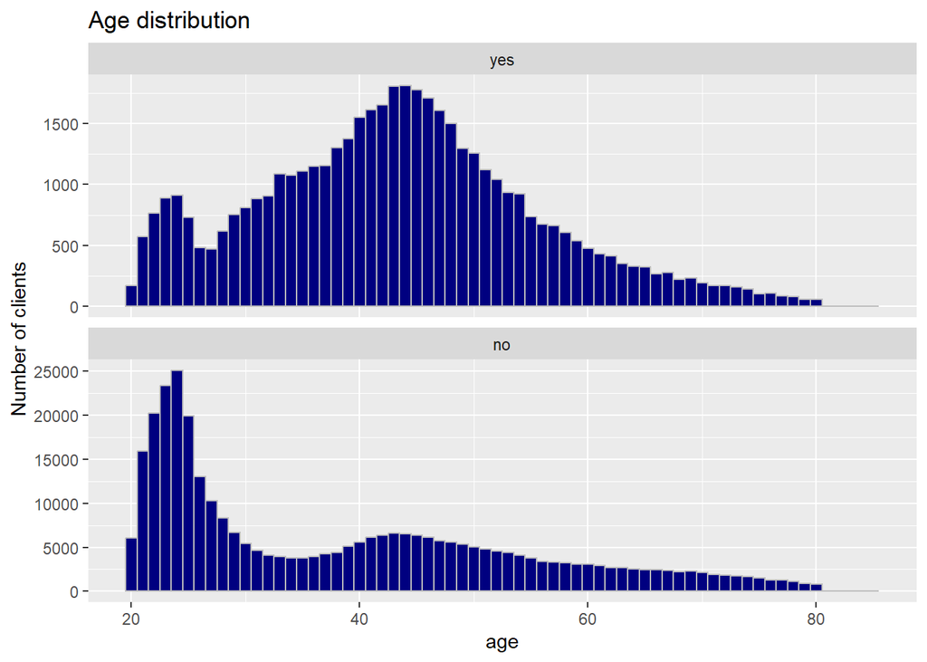

```r
# Boxplot
age_boxplot <- df_cleaned %>%
  ggplot(aes(x = response, y = age)) +
  stat_boxplot(geom = 'errorbar', width = 0.6) +
  geom_boxplot(aes(fill = response), show.legend = FALSE) +
  labs(title = "Age vs. Response Comparison", y = "Age", x = "Response") +
  theme_bw()

ggsave("img/age_boxplot.jpg", plot = age_boxplot, width = 6,
       height = 4)



# Histogram
age_plot <- df_cleaned %>%
  ggplot(aes(x = age)) +
  geom_histogram(binwidth = 1, color = "gray", fill="navy") +
  facet_wrap(vars(response), nrow = 2, scales = "free_y") +
  labs(y = "Number of clients") +
  ggtitle("Age distribution")

age_plot
```

```r
ggsave("img/age_plot.jpg", plot = age_plot, width = 6,
       height = 4)
```

```r
# Descriptive Statistics
df_cleaned %>%
  select(age, response) %>%
  tbl_summary(by = response) %>%
  add_p()
```

| **Characteristic** | **yes**, N = 46,710<sup>1</sup> | **no**, N = 334,399<sup>1</sup> | **p-value**<sup>2</sup> |
| --- | --- | --- | --- |
| age | 43 (35, 51) | 34 (24, 49) | <0.001 |

<sup>1</sup> Median (IQR)  
<sup>2</sup> Wilcoxon rank sum test

Young people seems to be less interested in the car insurance. The median age for intereseted customers is 43 years (IQR: 35, 51), while the median for non-interested customers is 34 years (IQR: 24, 49).

## 6.2 **H2) Women are likely to be interested in the car insurance.** ❌

```r
gender_plot <- df_cleaned %>%
  select(response, gender) %>%
  ggplot(aes(x = response)) +
  geom_bar(aes(fill = gender), position = 'dodge') +
  labs(title = "Gender vs. Response",
       x = "Response", y = "Number of customers") +
  theme_bw()

ggsave("img/gender_plot.png", plot = gender_plot)
```

```r
df_cleaned %>%
  select(response, gender) %>%
  tbl_summary(by = response) %>%
  add_p()
```

| **Characteristic** | **yes**, N = 46,710<sup>1</sup> | **no**, N = 334,399<sup>1</sup> | **p-value**<sup>2</sup> |
| --- | --- | --- | --- |
| gender |  |  | <0.001 |
| female | 18,185 (39%) | 156,835 (47%) |  |
| male | 28,525 (61%) | 177,564 (53%) |  |

<sup>1</sup> n (%)  
<sup>2</sup> Pearson’s Chi-squared test

For customers interested in the car insurance, 61% were men, and 39% were women. So, this hypothesis is FALSE. Although, gender and response are statistically significant, i. e., are related.

## 6.3 **H3) Customers having newer cars are more likely to be interested in the car insurance.** ❌

```r
car_age_plot <- df_cleaned %>%
  select(response, vehicle_age) %>%
  ggplot(aes(x = response)) +
  geom_bar(aes(fill = vehicle_age), position = 'dodge') +
  labs(title = "Vehicle Age vs. Response",
       x = "Response", y = "Number of customers") +
  theme_bw()

ggsave("img/car_age_plot.jpg", plot = car_age_plot)
```

```r
df_cleaned %>%
  select(response, vehicle_age) %>%
  tbl_summary(by = response) %>%
  add_p()
```

| **Characteristic** | **yes**, N = 46,710<sup>1</sup> | **no**, N = 334,399<sup>1</sup> | **p-value**<sup>2</sup> |
| --- | --- | --- | --- |
| vehicle_age |  |  | <0.001 |
| below_1_year | 7,202 (15%) | 157,584 (47%) |  |
| between_1_2_years | 34,806 (75%) | 165,510 (49%) |  |
| over_2_years | 4,702 (10%) | 11,305 (3.4%) |  |

<sup>1</sup> n (%)  
<sup>2</sup> Pearson’s Chi-squared test

Customers with cars aged between 1 and 2 years are more likely to be interested in the car insurance (75%). While, only 15% of the interested customers have newer cars.

## 6.4 **H4)** Customers with previous car damage are more likely to accept the car insurance ✅

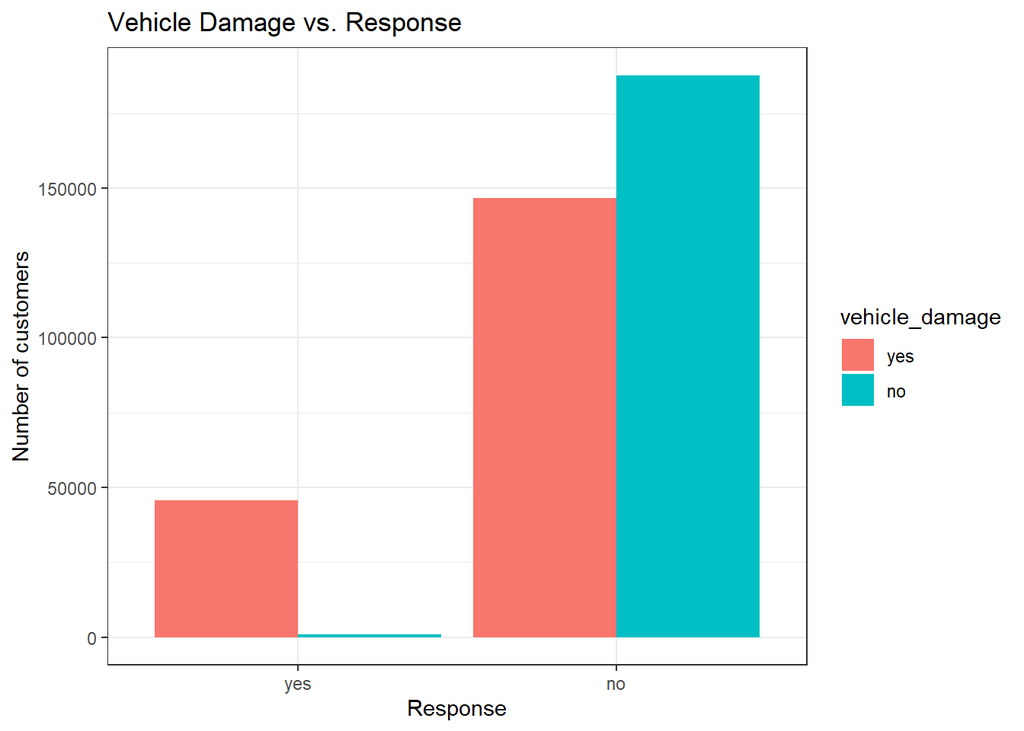

```r
car_damage_plot <- df_cleaned %>%
  select(response, vehicle_damage) %>%
  ggplot(aes(x = response)) +
  geom_bar(aes(fill = vehicle_damage), position = 'dodge') +
  labs(title = "Vehicle Damage vs. Response",
       x = "Response", y = "Number of customers") +
  theme_bw()

car_damage_plot
```

```r
ggsave("img/car_damage_plot.jpg", plot = car_damage_plot)
```

```r
df_cleaned %>%
  select(response, vehicle_damage) %>%
  tbl_summary(by = response) %>%
  add_p()
```

| **Characteristic** | **yes**, N = 46,710<sup>1</sup> | **no**, N = 334,399<sup>1</sup> | **p-value**<sup>2</sup> |
| --- | --- | --- | --- |
| vehicle_damage | 45,728 (98%) | 146,685 (44%) | <0.001 |

<sup>1</sup> n (%)  
<sup>2</sup> Pearson’s Chi-squared test

Customers with previous car damage are likely to be interested in the car insurance, as 98% said yes.

## 6.5 **H5)** Customers with previous car insurance are more likely to accept the car insurance ❌

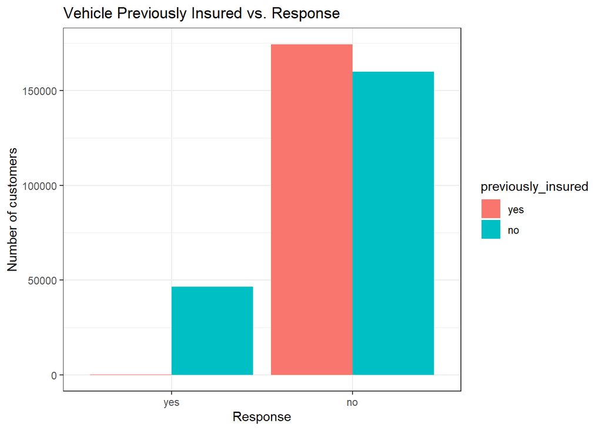

```r
car_insurance_plot <- df_cleaned %>%
  select(response, previously_insured) %>%
  ggplot(aes(x = response)) +
  geom_bar(aes(fill = previously_insured), position = 'dodge') +
  labs(title = "Vehicle Previously Insured vs. Response",
       x = "Response", y = "Number of customers") +
  theme_bw()
car_insurance_plot
```

```r
ggsave("img/car_insurance_plot.jpg", plot = car_insurance_plot)
```

```r
df_cleaned %>%
  select(response, previously_insured) %>%
  tbl_summary(by = response) %>%
  add_p()
```

| **Characteristic** | **yes**, N = 46,710<sup>1</sup> | **no**, N = 334,399<sup>1</sup> | **p-value**<sup>2</sup> |
| --- | --- | --- | --- |
| previously_insured | 158 (0.3%) | 174,470 (52%) | <0.001 |

<sup>1</sup> n (%)  
<sup>2</sup> Pearson’s Chi-squared test

Only 0.3% of customers interested in the car insurance have the car previously insured.

## 6.6 **H6) Interest is greater in customers with HIGHER ANNUAL HEALTH expenses.** ❌

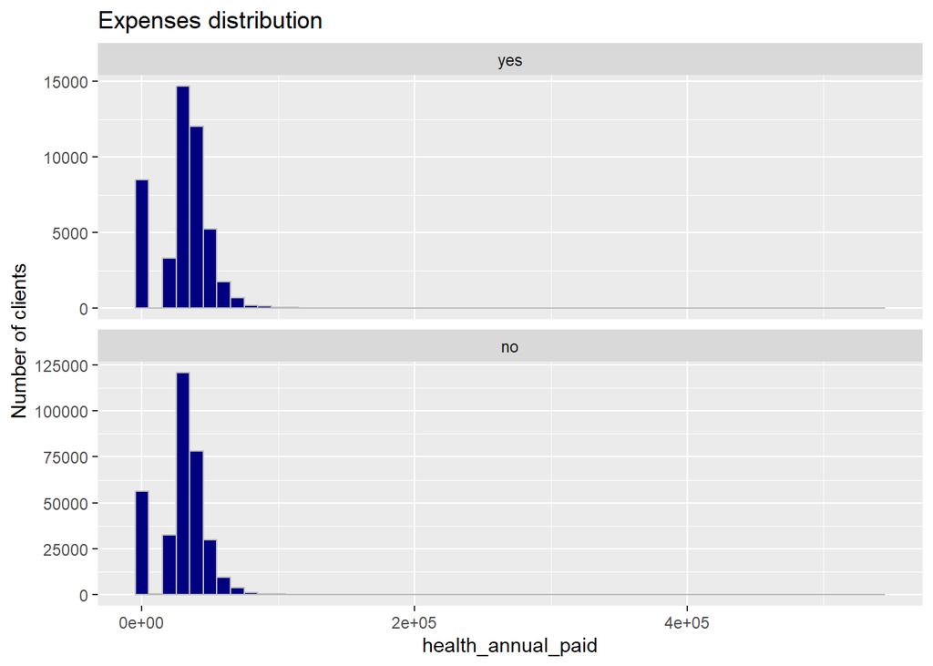

```r
# Boxplot
expenses_boxplot <- df_cleaned %>%
  ggplot(aes(x = response, y = health_annual_paid)) +
  stat_boxplot(geom = 'errorbar', width = 0.6) +
  geom_boxplot(aes(fill = response), show.legend = FALSE) +
  labs(title = "Annual Payment vs. Response Comparison",
       y = "Annual Payment", x = "Response") +
  theme_bw()

ggsave("img/expenses_boxplot.jpg",
       plot = expenses_boxplot, width = 6,
       height = 4)

# Histogram
expenses_plot <- df_cleaned %>%
  ggplot(aes(x = health_annual_paid)) +
  geom_histogram(binwidth = 10000, color = "gray", fill="navy") +
  facet_wrap(vars(response), nrow = 2, scales = "free_y") +
  labs(y = "Number of clients") +
  ggtitle("Expenses distribution")

expenses_plot
```

```r
ggsave("img/expenses_plot.jpg", plot = expenses_plot,
       width = 6,
       height = 4)
```

```r
# Descriptive Statistics
df_cleaned %>%
  select(response, health_annual_paid) %>%
  tbl_summary(by = response) %>%
  add_p()
```

| **Characteristic** | **yes**, N = 46,710<sup>1</sup> | **no**, N = 334,399<sup>1</sup> | **p-value**<sup>2</sup> |
| --- | --- | --- | --- |
| health_annual_paid | 33,002 (24,868, 41,297) | 31,504 (24,351, 39,120) | <0.001 |

<sup>1</sup> Median (IQR)  
<sup>2</sup> Wilcoxon rank sum test

Although the health annual paid showed to be significant, we consider this hypotheses FALSE, and will further investigate the outliers.

## 6.7 **H7) Customers with health insurance for MORE TIME are more likely to be interested in car insurance** ❌

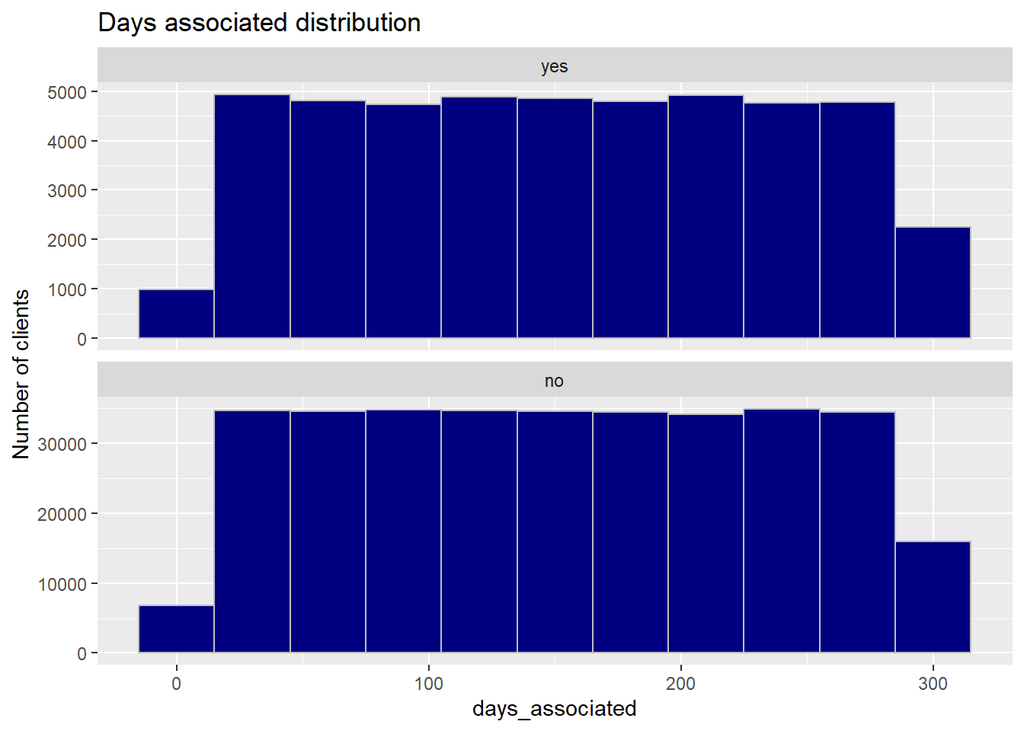

```r
# Boxplot
days_boxplot <- df_cleaned %>%
  ggplot(aes(x = response, y = days_associated)) +
  stat_boxplot(geom = 'errorbar', width = 0.6) +
  geom_boxplot(aes(fill = response), show.legend = FALSE) +
  labs(title = "Days associated vs. Response Comparison",
       y = "Days", x = "Response") +
  theme_bw()

ggsave("img/days_boxplot.jpg",
       plot = days_boxplot, width = 6,
       height = 4)

# Histogram
days_plot <- df_cleaned %>%
  ggplot(aes(x = days_associated)) +
  geom_histogram(binwidth = 30, color = "gray", fill="navy") +
  facet_wrap(vars(response), nrow = 2, scales = "free_y") +
  labs(y = "Number of clients") +
  ggtitle("Days associated distribution")

days_plot
```

```r
ggsave("img/days_plot.jpg", plot = days_plot,
       width = 6,
       height = 4)
```

```r
df_cleaned %>%
  select(response, days_associated) %>%
  tbl_summary(by = response) %>%
  add_p()
```

| **Characteristic** | **yes**, N = 46,710<sup>1</sup> | **no**, N = 334,399<sup>1</sup> | **p-value**<sup>2</sup> |
| --- | --- | --- | --- |
| days_associated | 154 (82, 226) | 154 (82, 227) | 0.5 |

<sup>1</sup> Median (IQR)  
<sup>2</sup> Wilcoxon rank sum test

This hypothesis is FALSE, basically the interested customers and non-interested customers have the same amount of days associated. Yes (median: 154 days, IQR: 82, 226); No (154 days, IQR: 82, 227).

## 6.8 Hypothesis conclusion

```r
hypothesis <- c(
  "H1) Customers with HIGHER AGE are more likely to be interested in the car insurance.",
  "H2) Women are likely to be interested in the car insurance.",
  "H3) Customers having newer cars are more likely to be interested in the car insurance.",
  "H4) Customers with previous car damage are more likely to accept the car insurance",
  "H5) Customers with previous car insurance are more likely to accept the car insurance",
  "H6) Interest is greater in customers with HIGHER ANNUAL HEALTH expenses.",
  "H7) Customers with health insurance for MORE TIME are more likely to be interested in car insurance "
  )

conclusion <- c(
  "True",
  "False",
  "False",
  "True",
  "False",
  "False",
  "False"
)

relevance <- c(
  "High",
  "Medium",
  "High",
  "High",
  "High",
  "Low",
  "Low"
)

hypothesis_table <- tibble(
  hypothesis = hypothesis,
  conclusion = conclusion,
  relevance = relevance
)

kable(hypothesis_table, format = "html") %>%
  kableExtra::kable_styling(bootstrap_options = "striped",
                            full_width = FALSE)
```

| hypothesis | conclusion | relevance |
| --- | --- | --- |
| H1) Customers with HIGHER AGE are more likely to be interested in the car insurance. | True | High |
| H2) Women are likely to be interested in the car insurance. | False | Medium |
| H3) Customers having newer cars are more likely to be interested in the car insurance. | False | High |
| H4) Customers with previous car damage are more likely to accept the car insurance | True | High |
| H5) Customers with previous car insurance are more likely to accept the car insurance | False | High |
| H6) Interest is greater in customers with HIGHER ANNUAL HEALTH expenses. | False | Low |
| H7) Customers with health insurance for MORE TIME are more likely to be interested in car insurance | False | Low |

# 7 Multivariable analysis

Correlation Matrix

```r
correlation_matrix <- df_cleaned %>%
  select(age, days_associated, health_annual_paid) %>%
  cor() %>%
  round(3)
```

- Visualization:

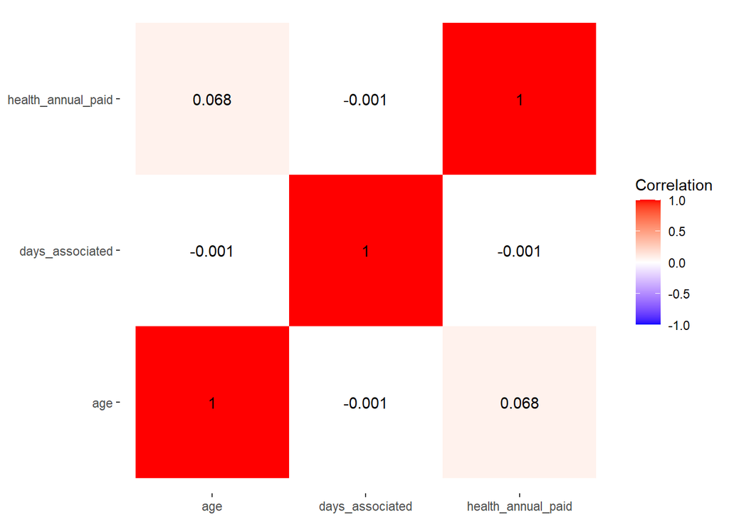

```r
melted_correlation <- melt(correlation_matrix)

matrix_correlation_plot <- ggplot(melted_correlation, aes(x = Var1, y = Var2, fill = value)) +
  geom_tile() +
  geom_text(aes(Var1, Var2, label = value)) +
  scale_fill_gradient2(low = "blue", high = "red",
                       limit = c(-1, 1), name = "Correlation") +
  theme(axis.title.x = element_blank(),
        axis.title.y = element_blank(),
        panel.background = element_blank())

matrix_correlation_plot
```

```r
ggsave("img/matrix_correlation_plot.jpg", matrix_correlation_plot,
       width = 8, height = 4)
```

There is no strong correlation among numerical variables.

# 8 Data Preparation

- **Frequency** encoding for `policy_sales_channel` | *Build Function ✅*
- **Target encoding** for `gender` e `region_code` | *Build Function ✅*

## 8.1 Target encoding

```r
# For gender
gender_encoder <- df_cleaned %>%
  mutate(response_num = ifelse(response == "yes", 1, 0)) %>%
  group_by(gender) %>%
  summarise(gender_num = mean(response_num, na.rm = TRUE))

# For region_code
region_encoder <- df_cleaned %>%
  mutate(response_num = ifelse(response == "yes", 1, 0)) %>%
  group_by(region_code) %>%
  summarise(region_num = mean(response_num, na.rm = TRUE))

# Save in rds
saveRDS(gender_encoder, "gender_encoder.rds")
saveRDS(region_encoder, "region_encoder.rds")
```

## 8.2 **Frequency encoding**

```r
policy_encoder <- df_cleaned %>%
  group_by(policy_sales_channel) %>%
  summarise(policy_num = n()/nrow(df_cleaned))

# Save in rds
saveRDS(policy_encoder, "policy_encoder.rds")
```

- Using the created encoders in our dataset:

  ```r
  # Create function
  encoder_function <- function(df){
    df %>%
    left_join(gender_encoder) %>%
    select(-gender) %>%
    rename(gender = gender_num) %>%
    left_join(region_encoder) %>%
    select(-region_code) %>%
    rename(region_code = region_num) %>%
    left_join(policy_encoder) %>%
    select(-policy_sales_channel) %>%
    rename(policy_sales_channel = policy_num)
  }
  ```

  ```r
  # Save function in rds
  saveRDS(encoder_function, "encoder_function.rds")
  ```

## Splitting into train and test datasets

  ```r
  encoder_function <- readRDS("encoder_function.rds")

  df_preprocessed <- encoder_function(df_cleaned)
  ```

  ```r
  set.seed(123)

  df_split <- df_preprocessed %>%
    initial_split(prop = 0.75, strata = response)

  df_train <- df_split %>%
    training()

  df_test <- df_split %>%
    testing()
  ```

- Check response proportions:

  ```r
  df_train %>%
    select(response) %>%
    tbl_summary(type = list(response ~ "categorical"))
  ```

  | **Characteristic** | **N = 285,831**<sup>1</sup> |
  | --- | --- |
  | response |  |
  | yes | 35,032 (12%) |
  | no | 250,799 (88%) |

  <sup>1</sup> n (%)

  ```r
  df_test %>%
    select(response) %>%
    tbl_summary(type = list(response ~ "categorical"))
  ```

  | **Characteristic** | **N = 95,278**<sup>1</sup> |
  | --- | --- |
  | response |  |
  | yes | 11,678 (12%) |
  | no | 83,600 (88%) |

  <sup>1</sup> n (%)

- Using tidymodels steps to continue the preprocessing:

```r
df_recipe <- recipe(response ~.,
       data = df_train) %>%
  step_normalize(age, days_associated) %>%
  step_scale(health_annual_paid) %>%
  step_dummy(all_nominal(), -all_outcomes())
```

- Applying the recipe:

```r
# Train the recipe
df_train_prep <- df_recipe %>%
  prep(training = df_train)

df_train_processed <- df_train_prep %>%
  bake(new_data = df_train)
```

```r
# For the test dataset
df_test_processed <- df_train_prep %>%
  bake(new_data = df_test)
```

# 9 Feature selection

```r
predictors <- df_train_processed %>%
  select(-id, -response)

target <- df_train_processed$response

# Check raw numbers
length(target)
```

```
## [1] 285831
```

```r
nrow(predictors)
```

```
## [1] 285831
```

```r
start_time <- Sys.time()

rf_model <- randomForest(predictors, target, ntree = 10,
                         importance = TRUE)

end_time <- Sys.time()

print(end_time - start_time)
```

```
## Time difference of 12.08474 secs
```

- Show results:

```r
importance(rf_model) %>% View()
```

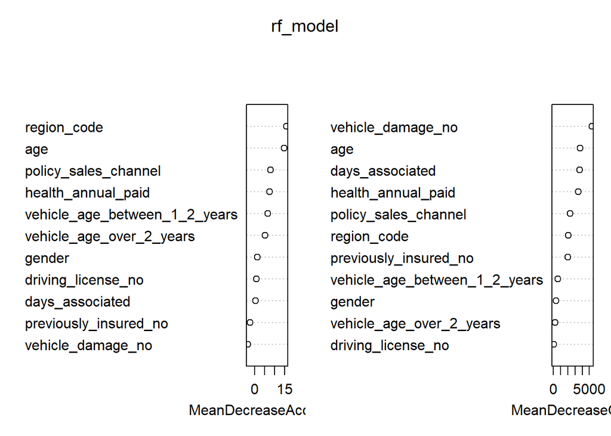

```r
varImpPlot(rf_model)
```

In this first cycle we are going to select the seven most important variables according to the Mean Decrease Gini:

```r
importance(rf_model) %>%
  as_tibble(rownames = "rowname") %>%
  arrange(desc(MeanDecreaseGini)) %>%
  select(rowname) %>%
  slice(1:7) %>%
  pull()
```

```
## [1] "vehicle_damage_no"     "age"                   "days_associated"
## [4] "health_annual_paid"    "policy_sales_channel"  "region_code"
## [7] "previously_insured_no"
```

```r
selected_columns <- c(
  "id",
  "age",
  "vehicle_damage",
  "days_associated",
  "previously_insured",
  "health_annual_paid",
  "policy_sales_channel",
  "region_code",
  "response"
)
```

```r
# Final dataset
df_selected <- df_cleaned %>%
  select(all_of(selected_columns))

saveRDS(df_selected, "df_selected.rds")
```